# Logistic regression

```r
date()
```

```
## [1] "Tue Nov 17 21:10:17 2020"
```

This chapter describes an application of logistic regression model.

## Data

The data of this chapter is student alcohol consumption data from [UCI Machine Learning Repository](https://archive.ics.uci.edu/ml/machine-learning-databases/00320/). It has been pre-processed using [the code](https://github.com/ritabei/IODS-project/blob/master/data/create_alc.R) in my GitHub repository. Data set consists of 35 variables and 370 observations. Information about the variables can be found [here](https://archive.ics.uci.edu/ml/datasets/Student+Performance). Additional *alc_use* variable was defined by taking the average of weekday and weekend alcohol use. Additional *high_use* variable was defined by assigning *TRUE* value if *alc_use* is higher than 2 and *FALSE* value otherwise.

```r
# Reading the data
alc <- read.csv('data/alc.csv')

# Printing out the names of the variables in the data
names(alc)
```

```
##  [1] "school"     "sex"        "age"        "address"    "famsize"
##  [6] "Pstatus"    "Medu"       "Fedu"       "Mjob"       "Fjob"
## [11] "reason"     "guardian"   "traveltime" "studytime"  "schoolsup"
## [16] "famsup"     "activities" "nursery"    "higher"     "internet"
## [21] "romantic"   "famrel"     "freetime"   "goout"      "Dalc"
## [26] "Walc"       "health"     "failures"   "paid"       "absences"
## [31] "G1"         "G2"         "G3"         "alc_use"    "high_use"
```

```r
# Looking at the dimensions of the data
dim(alc)
```

```
## [1] 370  35
```

```r
# Looking at the structure of the data
str(alc)
```

```
## 'data.frame':    370 obs. of  35 variables:
##  $ school    : chr  "GP" "GP" "GP" "GP" ...
##  $ sex       : chr  "F" "F" "F" "F" ...
##  $ age       : int  15 15 15 15 15 15 15 15 15 15 ...
##  $ address   : chr  "R" "R" "R" "R" ...
##  $ famsize   : chr  "GT3" "GT3" "GT3" "GT3" ...
##  $ Pstatus   : chr  "T" "T" "T" "T" ...
##  $ Medu      : int  1 1 2 2 3 3 3 2 3 3 ...
##  $ Fedu      : int  1 1 2 4 3 4 4 2 1 3 ...
##  $ Mjob      : chr  "at_home" "other" "at_home" "services" ...
##  $ Fjob      : chr  "other" "other" "other" "health" ...
##  $ reason    : chr  "home" "reputation" "reputation" "course" ...
##  $ guardian  : chr  "mother" "mother" "mother" "mother" ...
##  $ traveltime: int  2 1 1 1 2 1 2 2 2 1 ...
##  $ studytime : int  4 2 1 3 3 3 3 2 4 4 ...
```

[output cut: 21 more lines]

## Interesting variables and hypothesis

I think that these four variables could be related with alcohol consumption:

1. *sex*: males might have tendency to drink more;
2. *goout*: students who go out often can go for drinks with friends;
3. *famrel*: bad family relations could be a cause of drinking;
4. *studytime*: maybe more motivated students who spend more time studying are less likely to engage in drinking.

## Distributions of the chosen variables

```r
# Accessing the tidyverse libraries dplyr and ggplot2
library(dplyr)
library(ggplot2)
```

Let’s look at the distribution of *sex* variable.

```r
#Producing summary statistics of alcohol use
alc %>% group_by(sex, high_use) %>% summarise(count = n(),mean_alc_use = mean(alc_use))
```

```
## # A tibble: 4 x 4
## # Groups:   sex [2]
##   sex   high_use count mean_alc_use
##   <chr> <lgl>    <int>        <dbl>
## 1 F     FALSE      154         1.44
## 2 F     TRUE        41         2.54
## 3 M     FALSE      105         1.50
## 4 M     TRUE        70         3.36
```

It seems that more males have high alcohol consumption compared to female. My initial hypothesis was right.

Let’s look at distribution of *goout* variable.

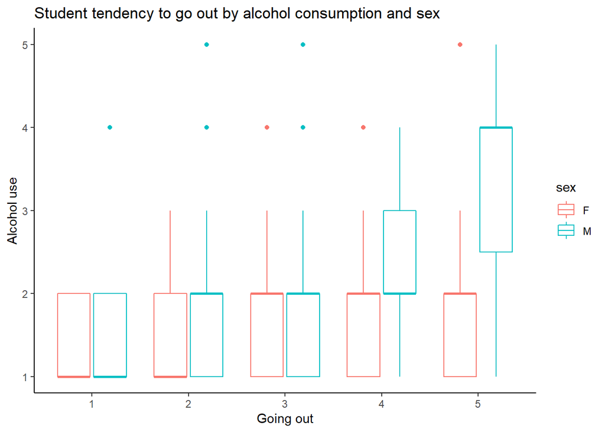

```r
# Initializing a plot of alc_use and going out
g2 <- ggplot(alc, aes(y = alc_use, x = factor(goout), col = sex))

# define the plot as a boxplot and draw it
g2 + geom_boxplot() + ggtitle("Student tendency to go out by alcohol consumption and sex") + theme_classic() + xlab('Going out') + ylab('Alcohol use')
```

Seems that students who tend to go out more, tend to drink more alcohol. My initial hypothesis was correct. Interestingly, for males, the median of alcohol consumption increases drastically if they go out with friends a lot. For females, median of alcohol consumption does not change between going out moderate amount of times and high amount of times.

Let’s look at *famrel* variable.

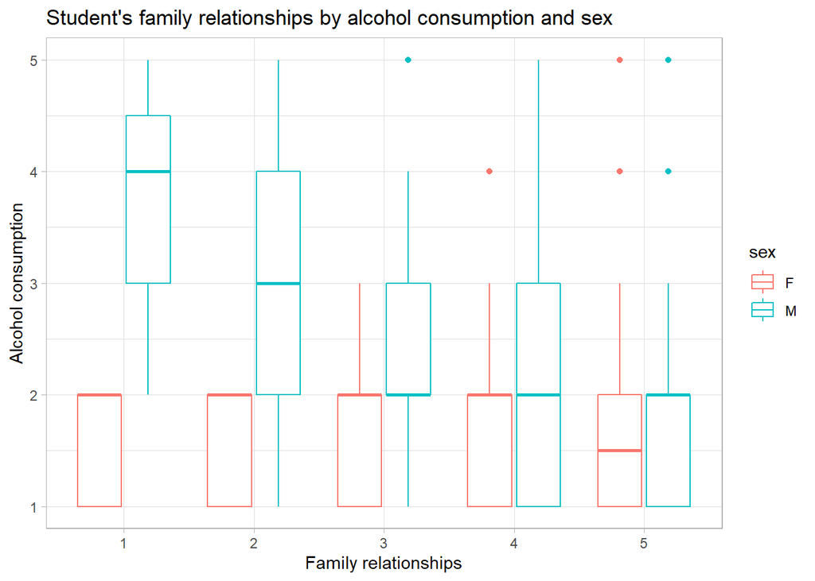

```r
# Initializing a plot of alc_use and family relationships
g2 <- ggplot(alc, aes(x = factor(famrel), y = alc_use, col = sex))

# define the plot as a boxplot and draw it
g2 + geom_boxplot() + ggtitle("Student's family relationships by alcohol consumption and sex") + xlab('Family relationships') + ylab('Alcohol consumption') + theme_light()
```

My initial hypothesis that family relationships are related to alcohol consumption is correct. It is clearly visible for males that the worse relationship is in family, the higher is alcohol consumption. For females, the median of alcohol consumption is similar except when family relationships are very good. In that case, alcohol consumption drops.

Let’s look at *studytime* variable.

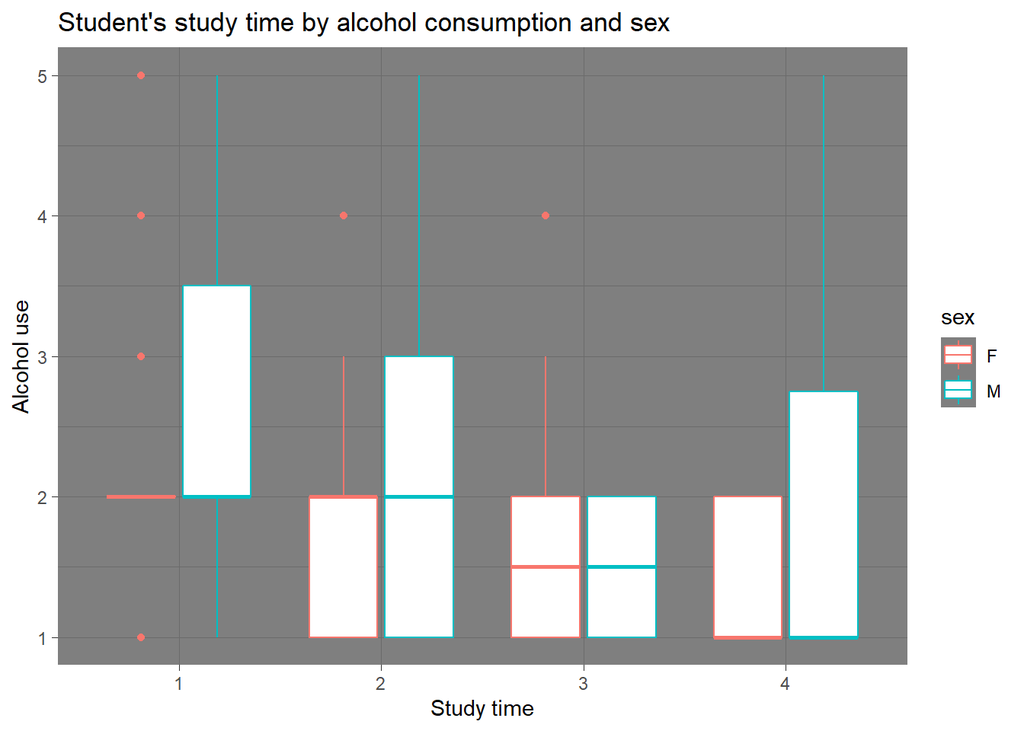

```r
# Initializing a plot of alc_use and study time
g2 <- ggplot(alc, aes(x = factor(studytime), y = alc_use, col = sex))

# define the plot as a boxplot and draw it
g2 + geom_boxplot() + ggtitle("Student's study time by alcohol consumption and sex") + theme_dark() + xlab('Study time') + ylab('Alcohol use')
```

My initial hypothesis was correct. For both males and females, alcohol consumption drops when study time increases.

## Logistic regression model

In this section logistic regression model will be fitted to explore the relationship between my chosen variables and the binary high/low alcohol consumption variable as the target variable.

```r
# Subsetting initial data frame to include only chosen variables and converting them to factors
alc_subset <- alc %>% select(high_use,sex,goout,famrel,studytime) %>% mutate(high_use = factor(high_use),
sex = factor(sex),
goout = factor(goout),
famrel = factor(famrel),
studytime = factor(studytime))
str(alc_subset)
```

```
## 'data.frame':    370 obs. of  5 variables:
##  $ high_use : Factor w/ 2 levels "FALSE","TRUE": 1 2 1 1 2 1 1 1 2 1 ...
##  $ sex      : Factor w/ 2 levels "F","M": 1 1 1 1 1 1 1 1 1 1 ...
##  $ goout    : Factor w/ 5 levels "1","2","3","4",..: 2 4 1 2 1 2 2 3 2 3 ...
##  $ famrel   : Factor w/ 5 levels "1","2","3","4",..: 3 3 4 4 4 4 4 4 4 4 ...
##  $ studytime: Factor w/ 4 levels "1","2","3","4": 4 2 1 3 3 3 3 2 4 4 ...
```

```r
# Finding the model with glm()
m <- glm(high_use ~ sex + goout + famrel + studytime, data = alc_subset, family = "binomial")

# Printing out a summary of the model
summary(m)
```

```
##
## Call:
## glm(formula = high_use ~ sex + goout + famrel + studytime, family = "binomial",
##     data = alc_subset)
##
## Deviance Residuals:
##     Min       1Q   Median       3Q      Max
## -1.6339  -0.7259  -0.4807   0.7514   2.5431
##
## Coefficients:
##             Estimate Std. Error z value Pr(>|z|)
## (Intercept) -1.62942    1.09247  -1.491 0.135833
## sexM         0.87854    0.27963   3.142 0.001679 **
## goout2       0.24560    0.69914   0.351 0.725369
## goout3       0.59346    0.68118   0.871 0.383636
## goout4       2.03442    0.68010   2.991 0.002778 **
## goout5       2.47951    0.70339   3.525 0.000423 ***
## famrel2      0.09062    1.05603   0.086 0.931619
## famrel3      0.17934    0.94055   0.191 0.848782
## famrel4     -0.51821    0.91743  -0.565 0.572171
## famrel5     -1.04992    0.94231  -1.114 0.265193
## studytime2  -0.34253    0.30894  -1.109 0.267537
## studytime3  -0.89382    0.48761  -1.833 0.066796 .
## studytime4  -1.29146    0.65058  -1.985 0.047136 *
## ---
## Signif. codes:  0 '***' 0.001 '**' 0.01 '*' 0.05 '.' 0.1 ' ' 1
##
## (Dispersion parameter for binomial family taken to be 1)
##
##     Null deviance: 452.04  on 369  degrees of freedom
## Residual deviance: 363.90  on 357  degrees of freedom
## AIC: 389.9
##
## Number of Fisher Scoring iterations: 5
```

As all variables in this model are factors, each of the variables are converted into so called dummy variables. The summary of the model shows that only all of *famrel* [dummy coded](https://stats.stackexchange.com/questions/60817/significance-of-categorical-predictor-in-logistic-regression) variables do not have statistically significant relationship with high alcohol consumption. For other variables, at least one of dummy variable has a statistically significant relationship.

```r
# Printing out the coefficients of the model
coef(m)
```

```
## (Intercept)        sexM      goout2      goout3      goout4      goout5
## -1.62941587  0.87853522  0.24560330  0.59345587  2.03442345  2.47950909
##     famrel2     famrel3     famrel4     famrel5  studytime2  studytime3
##  0.09061581  0.17933751 -0.51821396 -1.04991854 -0.34253287 -0.89381785
##  studytime4
## -1.29145540
```

```r
# Computing odds ratios (OR)
OR <- coef(m) %>% exp

# Computing confidence intervals (CI)
CI <- confint(m) %>% exp
# Printing out the odds ratios with their confidence intervals
cbind(OR, CI)
```

```
##                     OR      2.5 %     97.5 %
## (Intercept)  0.1960441 0.01756286  1.4112813
## sexM         2.4073708 1.39914040  4.1989737
## goout2       1.2783923 0.35906327  6.0626843
## goout3       1.8102336 0.53279909  8.3774038
## goout4       7.6478415 2.26873938 35.4135478
## goout5      11.9354038 3.36543311 57.2822325
## famrel2      1.0948483 0.15189997 10.7759938
## famrel3      1.1964245 0.21464931  9.9233767
## famrel4      0.5955833 0.11227629  4.7645467
## famrel5      0.3499663 0.06201071  2.8900970
## studytime2   0.7099698 0.38706568  1.3037798
## studytime3   0.4090909 0.15006032  1.0324002
## studytime4   0.2748704 0.06709430  0.9039728
```

*sexM*, all *goout* variables and *famrel2* as well as *famrel3* variables have OR > 1 which means greater odds of association with high alcohol consumption.

## Predictive power of the model

As *famrel* variable does not show statistical significance, let’s exclude it from the model.

```r
# Fitting the model with glm()
m <- glm(high_use ~ sex + goout + studytime, data = alc_subset, family = "binomial")

# predict() the probability of high_use
probabilities <- predict(m, type = "response")

# Adding the predicted probabilities to 'alc_subset'
alc_subset <- mutate(alc_subset, probability = probabilities)

# Using the probabilities to make a prediction of high_use
alc_subset <- mutate(alc_subset, prediction = probability > 0.5)

# Looking at the last ten original classes, predicted probabilities, and class predictions
tail(alc_subset, 10)
```

```
##     high_use sex goout famrel studytime probability prediction
## 361     TRUE   M     3      5         1   0.3531731      FALSE
## 362     TRUE   M     3      4         1   0.3531731      FALSE
## 363     TRUE   M     1      4         1   0.2321607      FALSE
## 364     TRUE   M     4      3         2   0.5923356       TRUE
## 365    FALSE   M     2      3         1   0.2877723      FALSE
## 366     TRUE   M     3      4         1   0.3531731      FALSE
## 367    FALSE   M     2      4         3   0.1213033      FALSE
## 368     TRUE   M     4      4         1   0.6891062       TRUE
## 369     TRUE   M     4      5         2   0.5923356       TRUE
## 370    FALSE   M     2      4         1   0.2877723      FALSE
```

```r
# Tabulating the target variable versus the predictions
table(high_use = alc_subset$high_use, prediction = alc_subset$prediction)
```

```
##         prediction
## high_use FALSE TRUE
##    FALSE   240   19
##    TRUE     58   53
```

Table of target variable versus the predictions show that most of students with low alcohol consumption are predicted correctly. Approximately half of students with high alcohol consumption are predicted correctly and half incorrectly.

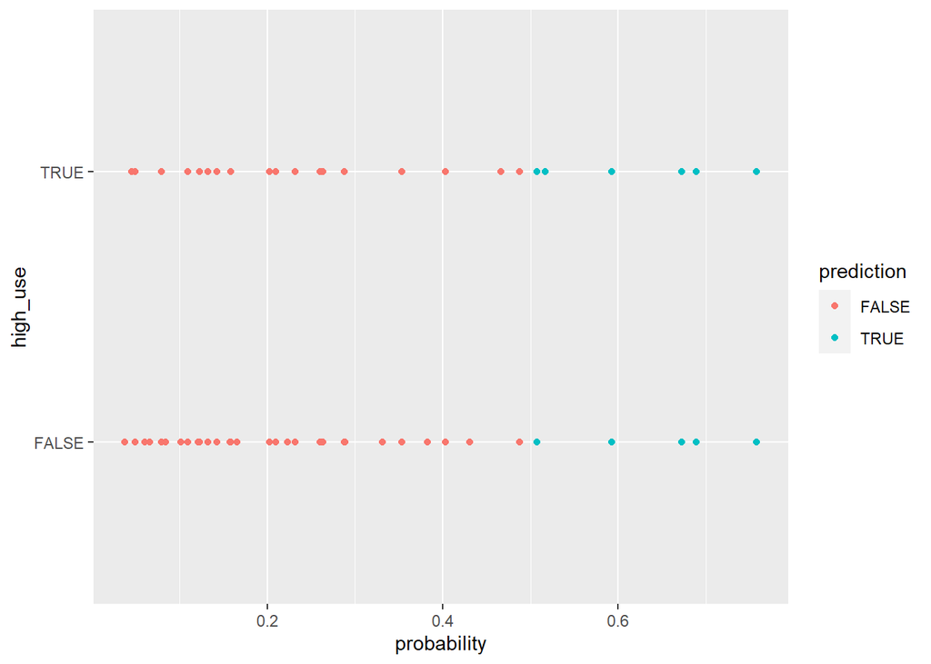

```r
# Initializing a plot of 'high_use' versus 'probability' in 'alc_subset'
g <- ggplot(alc_subset, aes(x = probability, y = high_use, col = prediction))

# Define the geom as points and draw the plot
g + geom_point()
```

The plot illustrates that many of the students with high alcohol consumption are not predicted correctly.

```r
# Define a loss function (average prediction error)
loss_func <- function(class, prob) {
  n_wrong <- abs(class - prob) > 0.5
  mean(n_wrong)
}

# Calling loss_func to compute the average number of wrong predictions in the (training) data
# alc_subset$high_use is a factor, therefore it needs to be converted into numeric vector.
# 1 is subracted because as.numeric() function converts True values to 2 and False values to 1
loss_func(class = as.numeric(alc_subset$high_use)-1,prob = alc_subset$probability)
```

```
## [1] 0.2081081
```

Now let’s look if model predicts better than random guessing.

```r
# Instead of probabilities predicted by the model, random sample of 0's and 1's is generated by sample() function
loss_func(class = as.numeric(alc_subset$high_use)-1,prob = sample(0:1, nrow(alc_subset), replace=T))
```

```
## [1] 0.527027
```

Logistic regression model has an error of 20% whereas random guessing gives error of 50% which means that logistic regression model is reasonably informative.

## Cross-validation

Let’s perform 10 fold cross validation.

```r
# K-fold cross-validation
library(boot)
cv <- cv.glm(data = alc_subset, cost = loss_func, glmfit = m, K = 10)

# Average number of wrong predictions in the cross validation
cv$delta[1]
```

```
## [1] 0.2162162
```